# SPSS_modexOutput

[output not shown]

Log  
Log - Log - October 15, 2017

* Encoding: UTF-8.  
* ========================================  
*  
* SPSS SYNTAX for lesson 14,15.  
*  
* for this code, use the modex.sav data file  
*  
* Melinda Higgins, PhD  
* dated 10/15/2017  
* ========================================.  
* ========================================  
* look at descriptive stats of the variables  
* ========================================.  
FREQUENCIES VARIABLES=Endurance Age AgeC Exercise ExerciseC AgeCxExerciseC  
/NTILES=4  
/STATISTICS=STDDEV MINIMUM MAXIMUM MEAN  
/HISTOGRAM  
/ORDER=ANALYSIS.

Frequencies  
Frequencies - Statistics - October 15, 2017

StatisticsStatistics, table, 1 levels of column headers and 2 levels of row headers, table with 8 columns and 11 rows

|  |  | Endurance | Age | AgeC | Exercise | ExerciseC | AgeCxExerciseC |
| --- | --- | --- | --- | --- | --- | --- | --- |
| N | Valid | 245 | 245 | 245 | 245 | 245 | 245 |
|  | Missing | 0 | 0 | 0 | 0 | 0 | 0 |
| Mean |  | 26.53 | 49.18 | .0037 | 10.67 | .0035 | 13.5865 |
| Std. Deviation |  | 10.819 | 10.107 | 10.10696 | 4.775 | 4.77523 | 46.00997 |
| Minimum |  | 0 | 20 | -29.18 | 0 | -10.67 | -131.55 |
| Maximum |  | 55 | 82 | 32.82 | 26 | 15.33 | 174.96 |
| Percentiles | 25 | 19.00 | 43.00 | -6.1800 | 7.00 | -3.6700 | -7.2494 |
|  | 50 | 27.00 | 48.00 | -1.1800 | 11.00 | .3300 | 4.5606 |
|  | 75 | 33.00 | 56.00 | 6.8200 | 14.00 | 3.3300 | 32.7806 |

Frequency Table  
Frequency Table - Endurance - October 15, 2017

EnduranceEndurance, table, 1 levels of column headers and 2 levels of row headers, table with 6 columns and 54 rows

|  |  | Frequency | Percent | Valid Percent | Cumulative Percent |
| --- | --- | --- | --- | --- | --- |
| Valid | 0 | 1 | .4 | .4 | .4 |
|  | 2 | 1 | .4 | .4 | .8 |
|  | 3 | 2 | .8 | .8 | 1.6 |
|  | 5 | 1 | .4 | .4 | 2.0 |
|  | 7 | 4 | 1.6 | 1.6 | 3.7 |
|  | 8 | 3 | 1.2 | 1.2 | 4.9 |
|  | 9 | 3 | 1.2 | 1.2 | 6.1 |
|  | 10 | 4 | 1.6 | 1.6 | 7.8 |
|  | 11 | 2 | .8 | .8 | 8.6 |
|  | 12 | 2 | .8 | .8 | 9.4 |
|  | 13 | 5 | 2.0 | 2.0 | 11.4 |
|  | 14 | 6 | 2.4 | 2.4 | 13.9 |
|  | 15 | 5 | 2.0 | 2.0 | 15.9 |
|  | 16 | 6 | 2.4 | 2.4 | 18.4 |
|  | 17 | 5 | 2.0 | 2.0 | 20.4 |
|  | 18 | 9 | 3.7 | 3.7 | 24.1 |
|  | 19 | 4 | 1.6 | 1.6 | 25.7 |
|  | 20 | 7 | 2.9 | 2.9 | 28.6 |
|  | 21 | 11 | 4.5 | 4.5 | 33.1 |
|  | 22 | 9 | 3.7 | 3.7 | 36.7 |
|  | 23 | 4 | 1.6 | 1.6 | 38.4 |
|  | 24 | 12 | 4.9 | 4.9 | 43.3 |
|  | 25 | 9 | 3.7 | 3.7 | 46.9 |
|  | 26 | 7 | 2.9 | 2.9 | 49.8 |
|  | 27 | 5 | 2.0 | 2.0 | 51.8 |
|  | 28 | 14 | 5.7 | 5.7 | 57.6 |
|  | 29 | 12 | 4.9 | 4.9 | 62.4 |
|  | 30 | 7 | 2.9 | 2.9 | 65.3 |
|  | 31 | 11 | 4.5 | 4.5 | 69.8 |
|  | 32 | 7 | 2.9 | 2.9 | 72.7 |
|  | 33 | 7 | 2.9 | 2.9 | 75.5 |
|  | 34 | 6 | 2.4 | 2.4 | 78.0 |
|  | 35 | 9 | 3.7 | 3.7 | 81.6 |
|  | 36 | 3 | 1.2 | 1.2 | 82.9 |
|  | 37 | 3 | 1.2 | 1.2 | 84.1 |
|  | 38 | 3 | 1.2 | 1.2 | 85.3 |
|  | 39 | 2 | .8 | .8 | 86.1 |
|  | 40 | 8 | 3.3 | 3.3 | 89.4 |
|  | 41 | 2 | .8 | .8 | 90.2 |
|  | 42 | 5 | 2.0 | 2.0 | 92.2 |
|  | 43 | 2 | .8 | .8 | 93.1 |
|  | 44 | 3 | 1.2 | 1.2 | 94.3 |
|  | 45 | 2 | .8 | .8 | 95.1 |
|  | 46 | 2 | .8 | .8 | 95.9 |
|  | 47 | 1 | .4 | .4 | 96.3 |
|  | 48 | 2 | .8 | .8 | 97.1 |
|  | 49 | 1 | .4 | .4 | 97.6 |
|  | 50 | 3 | 1.2 | 1.2 | 98.8 |
|  | 51 | 1 | .4 | .4 | 99.2 |
|  | 52 | 1 | .4 | .4 | 99.6 |
|  | 55 | 1 | .4 | .4 | 100.0 |
|  | Total | 245 | 100.0 | 100.0 |  |

Frequency Table  
Frequency Table - Age - October 15, 2017

AgeAge, table, 1 levels of column headers and 2 levels of row headers, table with 6 columns and 48 rows

|  |  | Frequency | Percent | Valid Percent | Cumulative Percent |
| --- | --- | --- | --- | --- | --- |
| Valid | 20 | 1 | .4 | .4 | .4 |
|  | 27 | 1 | .4 | .4 | .8 |
|  | 28 | 3 | 1.2 | 1.2 | 2.0 |
|  | 29 | 2 | .8 | .8 | 2.9 |
|  | 30 | 2 | .8 | .8 | 3.7 |
|  | 32 | 2 | .8 | .8 | 4.5 |
|  | 33 | 2 | .8 | .8 | 5.3 |
|  | 34 | 5 | 2.0 | 2.0 | 7.3 |
|  | 35 | 3 | 1.2 | 1.2 | 8.6 |
|  | 36 | 2 | .8 | .8 | 9.4 |
|  | 37 | 3 | 1.2 | 1.2 | 10.6 |
|  | 38 | 1 | .4 | .4 | 11.0 |
|  | 39 | 9 | 3.7 | 3.7 | 14.7 |
|  | 40 | 8 | 3.3 | 3.3 | 18.0 |
|  | 41 | 9 | 3.7 | 3.7 | 21.6 |
|  | 42 | 7 | 2.9 | 2.9 | 24.5 |
|  | 43 | 10 | 4.1 | 4.1 | 28.6 |
|  | 44 | 15 | 6.1 | 6.1 | 34.7 |
|  | 45 | 10 | 4.1 | 4.1 | 38.8 |
|  | 46 | 9 | 3.7 | 3.7 | 42.4 |
|  | 47 | 14 | 5.7 | 5.7 | 48.2 |
|  | 48 | 13 | 5.3 | 5.3 | 53.5 |
|  | 49 | 6 | 2.4 | 2.4 | 55.9 |
|  | 50 | 4 | 1.6 | 1.6 | 57.6 |
|  | 51 | 8 | 3.3 | 3.3 | 60.8 |
|  | 52 | 8 | 3.3 | 3.3 | 64.1 |
|  | 53 | 9 | 3.7 | 3.7 | 67.8 |
|  | 54 | 2 | .8 | .8 | 68.6 |
|  | 55 | 8 | 3.3 | 3.3 | 71.8 |
|  | 56 | 9 | 3.7 | 3.7 | 75.5 |
|  | 57 | 6 | 2.4 | 2.4 | 78.0 |
|  | 58 | 5 | 2.0 | 2.0 | 80.0 |
|  | 59 | 5 | 2.0 | 2.0 | 82.0 |
|  | 60 | 9 | 3.7 | 3.7 | 85.7 |
|  | 61 | 3 | 1.2 | 1.2 | 86.9 |
|  | 62 | 9 | 3.7 | 3.7 | 90.6 |
|  | 63 | 2 | .8 | .8 | 91.4 |
|  | 64 | 5 | 2.0 | 2.0 | 93.5 |
|  | 65 | 2 | .8 | .8 | 94.3 |
|  | 67 | 6 | 2.4 | 2.4 | 96.7 |
|  | 68 | 2 | .8 | .8 | 97.6 |
|  | 69 | 2 | .8 | .8 | 98.4 |
|  | 70 | 2 | .8 | .8 | 99.2 |
|  | 76 | 1 | .4 | .4 | 99.6 |
|  | 82 | 1 | .4 | .4 | 100.0 |
|  | Total | 245 | 100.0 | 100.0 |  |

Frequency Table  
Frequency Table - AgeC - October 15, 2017

AgeCAgeC, table, 1 levels of column headers and 2 levels of row headers, table with 6 columns and 48 rows

|  |  | Frequency | Percent | Valid Percent | Cumulative Percent |
| --- | --- | --- | --- | --- | --- |
| Valid | -29.18 | 1 | .4 | .4 | .4 |
|  | -22.18 | 1 | .4 | .4 | .8 |
|  | -21.18 | 3 | 1.2 | 1.2 | 2.0 |
|  | -20.18 | 2 | .8 | .8 | 2.9 |
|  | -19.18 | 2 | .8 | .8 | 3.7 |
|  | -17.18 | 2 | .8 | .8 | 4.5 |
|  | -16.18 | 2 | .8 | .8 | 5.3 |
|  | -15.18 | 5 | 2.0 | 2.0 | 7.3 |
|  | -14.18 | 3 | 1.2 | 1.2 | 8.6 |
|  | -13.18 | 2 | .8 | .8 | 9.4 |
|  | -12.18 | 3 | 1.2 | 1.2 | 10.6 |
|  | -11.18 | 1 | .4 | .4 | 11.0 |
|  | -10.18 | 9 | 3.7 | 3.7 | 14.7 |
|  | -9.18 | 8 | 3.3 | 3.3 | 18.0 |
|  | -8.18 | 9 | 3.7 | 3.7 | 21.6 |
|  | -7.18 | 7 | 2.9 | 2.9 | 24.5 |
|  | -6.18 | 10 | 4.1 | 4.1 | 28.6 |
|  | -5.18 | 15 | 6.1 | 6.1 | 34.7 |
|  | -4.18 | 10 | 4.1 | 4.1 | 38.8 |
|  | -3.18 | 9 | 3.7 | 3.7 | 42.4 |
|  | -2.18 | 14 | 5.7 | 5.7 | 48.2 |
|  | -1.18 | 13 | 5.3 | 5.3 | 53.5 |
|  | -.18 | 6 | 2.4 | 2.4 | 55.9 |
|  | .82 | 4 | 1.6 | 1.6 | 57.6 |
|  | 1.82 | 8 | 3.3 | 3.3 | 60.8 |
|  | 2.82 | 8 | 3.3 | 3.3 | 64.1 |
|  | 3.82 | 9 | 3.7 | 3.7 | 67.8 |
|  | 4.82 | 2 | .8 | .8 | 68.6 |
|  | 5.82 | 8 | 3.3 | 3.3 | 71.8 |
|  | 6.82 | 9 | 3.7 | 3.7 | 75.5 |
|  | 7.82 | 6 | 2.4 | 2.4 | 78.0 |
|  | 8.82 | 5 | 2.0 | 2.0 | 80.0 |
|  | 9.82 | 5 | 2.0 | 2.0 | 82.0 |
|  | 10.82 | 9 | 3.7 | 3.7 | 85.7 |
|  | 11.82 | 3 | 1.2 | 1.2 | 86.9 |
|  | 12.82 | 9 | 3.7 | 3.7 | 90.6 |
|  | 13.82 | 2 | .8 | .8 | 91.4 |
|  | 14.82 | 5 | 2.0 | 2.0 | 93.5 |
|  | 15.82 | 2 | .8 | .8 | 94.3 |
|  | 17.82 | 6 | 2.4 | 2.4 | 96.7 |
|  | 18.82 | 2 | .8 | .8 | 97.6 |
|  | 19.82 | 2 | .8 | .8 | 98.4 |
|  | 20.82 | 2 | .8 | .8 | 99.2 |
|  | 26.82 | 1 | .4 | .4 | 99.6 |
|  | 32.82 | 1 | .4 | .4 | 100.0 |
|  | Total | 245 | 100.0 | 100.0 |  |

Frequency Table  
Frequency Table - Exercise - October 15, 2017

ExerciseExercise, table, 1 levels of column headers and 2 levels of row headers, table with 6 columns and 30 rows

|  |  | Frequency | Percent | Valid Percent | Cumulative Percent |
| --- | --- | --- | --- | --- | --- |
| Valid | 0 | 3 | 1.2 | 1.2 | 1.2 |
|  | 1 | 1 | .4 | .4 | 1.6 |
|  | 2 | 5 | 2.0 | 2.0 | 3.7 |
|  | 3 | 7 | 2.9 | 2.9 | 6.5 |
|  | 4 | 10 | 4.1 | 4.1 | 10.6 |
|  | 5 | 10 | 4.1 | 4.1 | 14.7 |
|  | 6 | 16 | 6.5 | 6.5 | 21.2 |
|  | 7 | 14 | 5.7 | 5.7 | 26.9 |
|  | 8 | 8 | 3.3 | 3.3 | 30.2 |
|  | 9 | 18 | 7.3 | 7.3 | 37.6 |
|  | 10 | 24 | 9.8 | 9.8 | 47.3 |
|  | 11 | 26 | 10.6 | 10.6 | 58.0 |
|  | 12 | 19 | 7.8 | 7.8 | 65.7 |
|  | 13 | 20 | 8.2 | 8.2 | 73.9 |
|  | 14 | 20 | 8.2 | 8.2 | 82.0 |
|  | 15 | 12 | 4.9 | 4.9 | 86.9 |
|  | 16 | 9 | 3.7 | 3.7 | 90.6 |
|  | 17 | 5 | 2.0 | 2.0 | 92.7 |
|  | 18 | 5 | 2.0 | 2.0 | 94.7 |
|  | 19 | 3 | 1.2 | 1.2 | 95.9 |
|  | 20 | 3 | 1.2 | 1.2 | 97.1 |
|  | 21 | 1 | .4 | .4 | 97.6 |
|  | 22 | 2 | .8 | .8 | 98.4 |
|  | 23 | 1 | .4 | .4 | 98.8 |
|  | 24 | 1 | .4 | .4 | 99.2 |
|  | 25 | 1 | .4 | .4 | 99.6 |
|  | 26 | 1 | .4 | .4 | 100.0 |
|  | Total | 245 | 100.0 | 100.0 |  |

Frequency Table  
Frequency Table - ExerciseC - October 15, 2017

ExerciseCExerciseC, table, 1 levels of column headers and 2 levels of row headers, table with 6 columns and 30 rows

|  |  | Frequency | Percent | Valid Percent | Cumulative Percent |
| --- | --- | --- | --- | --- | --- |
| Valid | -10.67 | 3 | 1.2 | 1.2 | 1.2 |
|  | -9.67 | 1 | .4 | .4 | 1.6 |
|  | -8.67 | 5 | 2.0 | 2.0 | 3.7 |
|  | -7.67 | 7 | 2.9 | 2.9 | 6.5 |
|  | -6.67 | 10 | 4.1 | 4.1 | 10.6 |
|  | -5.67 | 10 | 4.1 | 4.1 | 14.7 |
|  | -4.67 | 16 | 6.5 | 6.5 | 21.2 |
|  | -3.67 | 14 | 5.7 | 5.7 | 26.9 |
|  | -2.67 | 8 | 3.3 | 3.3 | 30.2 |
|  | -1.67 | 18 | 7.3 | 7.3 | 37.6 |
|  | -.67 | 24 | 9.8 | 9.8 | 47.3 |
|  | .33 | 26 | 10.6 | 10.6 | 58.0 |
|  | 1.33 | 19 | 7.8 | 7.8 | 65.7 |
|  | 2.33 | 20 | 8.2 | 8.2 | 73.9 |
|  | 3.33 | 20 | 8.2 | 8.2 | 82.0 |
|  | 4.33 | 12 | 4.9 | 4.9 | 86.9 |
|  | 5.33 | 9 | 3.7 | 3.7 | 90.6 |
|  | 6.33 | 5 | 2.0 | 2.0 | 92.7 |
|  | 7.33 | 5 | 2.0 | 2.0 | 94.7 |
|  | 8.33 | 3 | 1.2 | 1.2 | 95.9 |
|  | 9.33 | 3 | 1.2 | 1.2 | 97.1 |
|  | 10.33 | 1 | .4 | .4 | 97.6 |
|  | 11.33 | 2 | .8 | .8 | 98.4 |
|  | 12.33 | 1 | .4 | .4 | 98.8 |
|  | 13.33 | 1 | .4 | .4 | 99.2 |
|  | 14.33 | 1 | .4 | .4 | 99.6 |
|  | 15.33 | 1 | .4 | .4 | 100.0 |
|  | Total | 245 | 100.0 | 100.0 |  |

Frequency Table  
Frequency Table - AgeCxExerciseC - October 15, 2017

AgeCxExerciseCAgeCxExerciseC, table, 1 levels of column headers and 2 levels of row headers, table with 6 columns and 202 rows

|  |  | Frequency | Percent | Valid Percent | Cumulative Percent |
| --- | --- | --- | --- | --- | --- |
| Valid | -131.55 | 1 | .4 | .4 | .4 |
|  | -113.64 | 1 | .4 | .4 | .8 |
|  | -89.76 | 1 | .4 | .4 | 1.2 |
|  | -89.70 | 1 | .4 | .4 | 1.6 |
|  | -76.32 | 1 | .4 | .4 | 2.0 |
|  | -72.77 | 1 | .4 | .4 | 2.4 |
|  | -72.17 | 1 | .4 | .4 | 2.9 |
|  | -70.53 | 1 | .4 | .4 | 3.3 |
|  | -65.50 | 1 | .4 | .4 | 3.7 |
|  | -64.44 | 1 | .4 | .4 | 4.1 |
|  | -59.96 | 1 | .4 | .4 | 4.5 |
|  | -59.87 | 1 | .4 | .4 | 4.9 |
|  | -54.39 | 1 | .4 | .4 | 5.3 |
|  | -51.48 | 1 | .4 | .4 | 5.7 |
|  | -50.53 | 2 | .8 | .8 | 6.5 |
|  | -49.35 | 1 | .4 | .4 | 6.9 |
|  | -47.58 | 1 | .4 | .4 | 7.3 |
|  | -47.22 | 1 | .4 | .4 | 7.8 |
|  | -39.75 | 1 | .4 | .4 | 8.2 |
|  | -39.71 | 1 | .4 | .4 | 8.6 |
|  | -35.37 | 1 | .4 | .4 | 9.0 |
|  | -32.79 | 1 | .4 | .4 | 9.4 |
|  | -30.64 | 1 | .4 | .4 | 9.8 |
|  | -29.76 | 1 | .4 | .4 | 10.2 |
|  | -29.30 | 1 | .4 | .4 | 10.6 |
|  | -28.38 | 1 | .4 | .4 | 11.0 |
|  | -26.49 | 1 | .4 | .4 | 11.4 |
|  | -26.22 | 1 | .4 | .4 | 11.8 |
|  | -23.91 | 1 | .4 | .4 | 12.2 |
|  | -23.72 | 1 | .4 | .4 | 12.7 |

[output cut: 170 more lines]

Histogram  
Histogram - Endurance - October 15, 2017

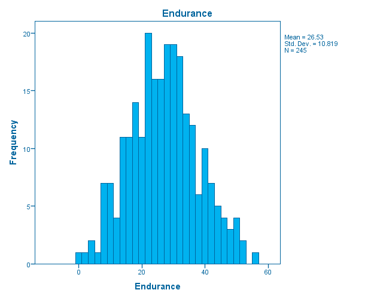

Histogram  
Histogram - Age - October 15, 2017

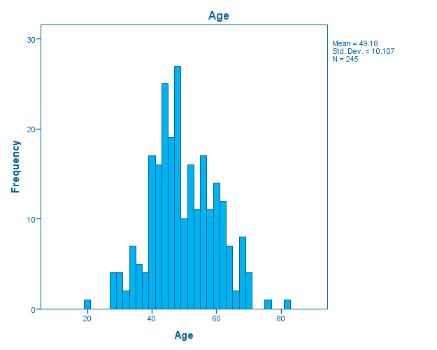

Histogram  
Histogram - AgeC - October 15, 2017

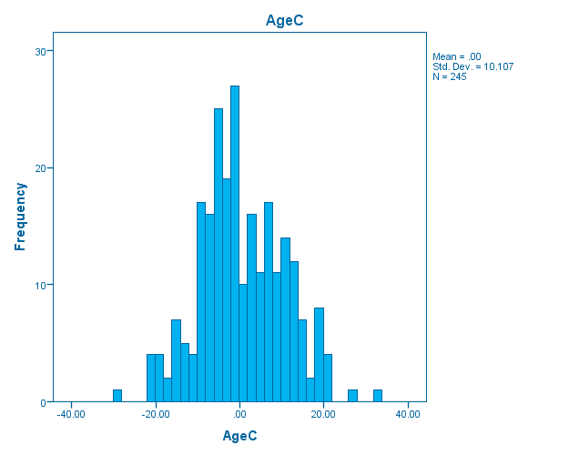

Histogram  
Histogram - Exercise - October 15, 2017

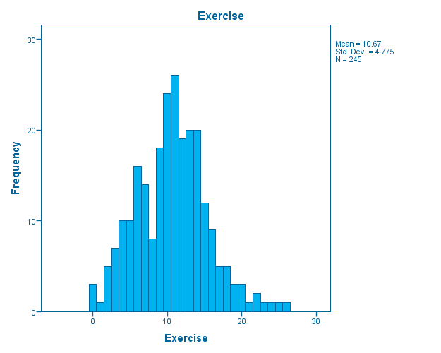

Histogram  
Histogram - ExerciseC - October 15, 2017

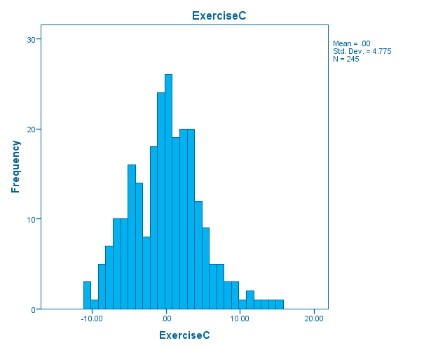

Histogram  
Histogram - AgeCxExerciseC - October 15, 2017

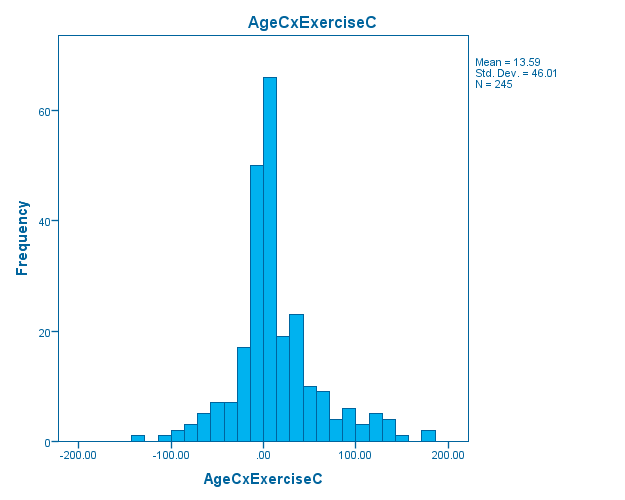

Log  
Log - Log - October 15, 2017

* ========================================  
* run a regression of Endurance by Age  
* ========================================.  
REGRESSION  
/DESCRIPTIVES MEAN STDDEV CORR SIG N  
/MISSING LISTWISE  
/STATISTICS COEFF OUTS CI(95) R ANOVA COLLIN TOL CHANGE ZPP  
/CRITERIA=PIN(.05) POUT(.10)  
/NOORIGIN  
/DEPENDENT Endurance  
/METHOD=ENTER Age.

Regression  
Regression - Descriptive Statistics - October 15, 2017

Descriptive StatisticsDescriptive Statistics, table, 1 levels of column headers and 1 levels of row headers, table with 4 columns and 4 rows

|  | Mean | Std. Deviation | N |
| --- | --- | --- | --- |
| Endurance | 26.53 | 10.819 | 245 |
| Age | 49.18 | 10.107 | 245 |

Regression  
Regression - Correlations - October 15, 2017

CorrelationsCorrelations, table, 1 levels of column headers and 2 levels of row headers, table with 4 columns and 8 rows

|  |  | Endurance | Age |
| --- | --- | --- | --- |
| Pearson Correlation | Endurance | 1.000 | -.126 |
|  | Age | -.126 | 1.000 |
| Sig. (1-tailed) | Endurance | . | .025 |
|  | Age | .025 | . |
| N | Endurance | 245 | 245 |
|  | Age | 245 | 245 |

Regression  
Regression - Variables Entered/Removed - October 15, 2017

Variables Entered/Removed<sup>a</sup>Variables Entered/Removed, table, 1 levels of column headers and 1 levels of row headers, table with 4 columns and 5 rows

| Model | Variables Entered | Variables Removed | Method |
| --- | --- | --- | --- |
| 1 | Age<sup>b</sup> | . | Enter |

a. Dependent Variable: Endurance  
b. All requested variables entered.

Regression  
Regression - Model Summary - October 15, 2017

Model SummaryModel Summary, table, 2 levels of column headers and 1 levels of row headers, table with 10 columns and 5 rows

| Model | R | R Square | Adjusted R Square | Std. Error of the Estimate | Change Statistics |  |  |  |  |
| --- | --- | --- | --- | --- | --- | --- | --- | --- | --- |
|  |  |  |  |  | R Square Change | F Change | df1 | df2 | Sig. F Change |
| 1 | .126<sup>a</sup> | .016 | .012 | 10.755 | .016 | 3.911 | 1 | 243 | .049 |

a. Predictors: (Constant), Age

Regression  
Regression - ANOVA - October 15, 2017

ANOVA<sup>a</sup>ANOVA, table, 1 levels of column headers and 2 levels of row headers, table with 7 columns and 7 rows

| Model |  | Sum of Squares | df | Mean Square | F | Sig. |
| --- | --- | --- | --- | --- | --- | --- |
| 1 | Regression | 452.376 | 1 | 452.376 | 3.911 | .049<sup>b</sup> |
|  | Residual | 28108.645 | 243 | 115.673 |  |  |
|  | Total | 28561.020 | 244 |  |  |  |

a. Dependent Variable: Endurance  
b. Predictors: (Constant), Age

Regression  
Regression - Coefficients - October 15, 2017

Coefficients<sup>a</sup>Coefficients, table, 2 levels of column headers and 2 levels of row headers, table with 14 columns and 6 rows

| Model |  | Unstandardized Coefficients |  | Standardized Coefficients | t | Sig. | 95.0% Confidence Interval for B |  | Correlations |  |  | Collinearity Statistics |  |
| --- | --- | --- | --- | --- | --- | --- | --- | --- | --- | --- | --- | --- | --- |
|  |  | B | Std. Error | Beta |  |  | Lower Bound | Upper Bound | Zero-order | Partial | Part | Tolerance | VIF |
| 1 | (Constant) | 33.157 | 3.420 |  | 9.694 | .000 | 26.419 | 39.894 |  |  |  |  |  |
|  | Age | -.135 | .068 | -.126 | -1.978 | .049 | -.269 | -.001 | -.126 | -.126 | -.126 | 1.000 | 1.000 |

a. Dependent Variable: Endurance

Regression  
Regression - Collinearity Diagnostics - October 15, 2017

Collinearity Diagnostics<sup>a</sup>Collinearity Diagnostics, table, 2 levels of column headers and 2 levels of row headers, table with 6 columns and 6 rows

| Model | Dimension | Eigenvalue | Condition Index | Variance Proportions |  |
| --- | --- | --- | --- | --- | --- |
|  |  |  |  | (Constant) | Age |
| 1 | 1 | 1.980 | 1.000 | .01 | .01 |
|  | 2 | .020 | 9.854 | .99 | .99 |

a. Dependent Variable: Endurance

Log  
Log - Log - October 15, 2017

* ========================================  
* run a regression of Endurance by mean centered Age  
* notice the slope is the same and the intercept has changed  
* compare the intercept to the mean for Endurance in the  
* descriptive stats above  
* ========================================.  
REGRESSION  
/DESCRIPTIVES MEAN STDDEV CORR SIG N  
/MISSING LISTWISE  
/STATISTICS COEFF OUTS CI(95) R ANOVA COLLIN TOL CHANGE ZPP  
/CRITERIA=PIN(.05) POUT(.10)  
/NOORIGIN  
/DEPENDENT Endurance  
/METHOD=ENTER AgeC.

Regression  
Regression - Descriptive Statistics - October 15, 2017

Descriptive StatisticsDescriptive Statistics, table, 1 levels of column headers and 1 levels of row headers, table with 4 columns and 4 rows

|  | Mean | Std. Deviation | N |
| --- | --- | --- | --- |
| Endurance | 26.53 | 10.819 | 245 |
| AgeC | .0037 | 10.10696 | 245 |

Regression  
Regression - Correlations - October 15, 2017

CorrelationsCorrelations, table, 1 levels of column headers and 2 levels of row headers, table with 4 columns and 8 rows

|  |  | Endurance | AgeC |
| --- | --- | --- | --- |
| Pearson Correlation | Endurance | 1.000 | -.126 |
|  | AgeC | -.126 | 1.000 |
| Sig. (1-tailed) | Endurance | . | .025 |
|  | AgeC | .025 | . |
| N | Endurance | 245 | 245 |
|  | AgeC | 245 | 245 |

Regression  
Regression - Variables Entered/Removed - October 15, 2017

Variables Entered/Removed<sup>a</sup>Variables Entered/Removed, table, 1 levels of column headers and 1 levels of row headers, table with 4 columns and 5 rows

| Model | Variables Entered | Variables Removed | Method |
| --- | --- | --- | --- |
| 1 | AgeC<sup>b</sup> | . | Enter |

a. Dependent Variable: Endurance  
b. All requested variables entered.

Regression  
Regression - Model Summary - October 15, 2017

Model SummaryModel Summary, table, 2 levels of column headers and 1 levels of row headers, table with 10 columns and 5 rows

| Model | R | R Square | Adjusted R Square | Std. Error of the Estimate | Change Statistics |  |  |  |  |
| --- | --- | --- | --- | --- | --- | --- | --- | --- | --- |
|  |  |  |  |  | R Square Change | F Change | df1 | df2 | Sig. F Change |
| 1 | .126<sup>a</sup> | .016 | .012 | 10.755 | .016 | 3.911 | 1 | 243 | .049 |

a. Predictors: (Constant), AgeC

Regression  
Regression - ANOVA - October 15, 2017

ANOVA<sup>a</sup>ANOVA, table, 1 levels of column headers and 2 levels of row headers, table with 7 columns and 7 rows

| Model |  | Sum of Squares | df | Mean Square | F | Sig. |
| --- | --- | --- | --- | --- | --- | --- |
| 1 | Regression | 452.376 | 1 | 452.376 | 3.911 | .049<sup>b</sup> |
|  | Residual | 28108.645 | 243 | 115.673 |  |  |
|  | Total | 28561.020 | 244 |  |  |  |

a. Dependent Variable: Endurance  
b. Predictors: (Constant), AgeC

Regression  
Regression - Coefficients - October 15, 2017

Coefficients<sup>a</sup>Coefficients, table, 2 levels of column headers and 2 levels of row headers, table with 14 columns and 6 rows

| Model |  | Unstandardized Coefficients |  | Standardized Coefficients | t | Sig. | 95.0% Confidence Interval for B |  | Correlations |  |  | Collinearity Statistics |  |
| --- | --- | --- | --- | --- | --- | --- | --- | --- | --- | --- | --- | --- | --- |
|  |  | B | Std. Error | Beta |  |  | Lower Bound | Upper Bound | Zero-order | Partial | Part | Tolerance | VIF |
| 1 | (Constant) | 26.531 | .687 |  | 38.612 | .000 | 25.178 | 27.885 |  |  |  |  |  |
|  | AgeC | -.135 | .068 | -.126 | -1.978 | .049 | -.269 | -.001 | -.126 | -.126 | -.126 | 1.000 | 1.000 |

a. Dependent Variable: Endurance

Regression  
Regression - Collinearity Diagnostics - October 15, 2017

Collinearity Diagnostics<sup>a</sup>Collinearity Diagnostics, table, 2 levels of column headers and 2 levels of row headers, table with 6 columns and 6 rows

| Model | Dimension | Eigenvalue | Condition Index | Variance Proportions |  |
| --- | --- | --- | --- | --- | --- |
|  |  |  |  | (Constant) | AgeC |
| 1 | 1 | 1.000 | 1.000 | .50 | .50 |
|  | 2 | 1.000 | 1.000 | .50 | .50 |

a. Dependent Variable: Endurance

Log  
Log - Log - October 15, 2017

* ========================================  
* run a regression of Endurance - consider Exercise  
* "adjusting" for Age - BUT treating Age as a "covariate"  
* in this way assumes that the slope between  
* Exercise and Endurance is the same for ALL Ages  
* this is the homogeneity of slopes assumption  
* ========================================.  
REGRESSION  
/DESCRIPTIVES MEAN STDDEV CORR SIG N  
/MISSING LISTWISE  
/STATISTICS COEFF OUTS CI(95) R ANOVA COLLIN TOL CHANGE ZPP  
/CRITERIA=PIN(.05) POUT(.10)  
/NOORIGIN  
/DEPENDENT Endurance  
/METHOD=ENTER AgeC  
/METHOD=ENTER ExerciseC.

Regression  
Regression - Descriptive Statistics - October 15, 2017

Descriptive StatisticsDescriptive Statistics, table, 1 levels of column headers and 1 levels of row headers, table with 4 columns and 5 rows

|  | Mean | Std. Deviation | N |
| --- | --- | --- | --- |
| Endurance | 26.53 | 10.819 | 245 |
| AgeC | .0037 | 10.10696 | 245 |
| ExerciseC | .0035 | 4.77523 | 245 |

Regression  
Regression - Correlations - October 15, 2017

CorrelationsCorrelations, table, 1 levels of column headers and 2 levels of row headers, table with 5 columns and 11 rows

|  |  | Endurance | AgeC | ExerciseC |
| --- | --- | --- | --- | --- |
| Pearson Correlation | Endurance | 1.000 | -.126 | .337 |
|  | AgeC | -.126 | 1.000 | .283 |
|  | ExerciseC | .337 | .283 | 1.000 |
| Sig. (1-tailed) | Endurance | . | .025 | .000 |
|  | AgeC | .025 | . | .000 |
|  | ExerciseC | .000 | .000 | . |
| N | Endurance | 245 | 245 | 245 |
|  | AgeC | 245 | 245 | 245 |
|  | ExerciseC | 245 | 245 | 245 |

Regression  
Regression - Variables Entered/Removed - October 15, 2017

Variables Entered/Removed<sup>a</sup>Variables Entered/Removed, table, 1 levels of column headers and 1 levels of row headers, table with 4 columns and 6 rows

| Model | Variables Entered | Variables Removed | Method |
| --- | --- | --- | --- |
| 1 | AgeC<sup>b</sup> | . | Enter |
| 2 | ExerciseC<sup>b</sup> | . | Enter |

a. Dependent Variable: Endurance  
b. All requested variables entered.

Regression  
Regression - Model Summary - October 15, 2017

Model SummaryModel Summary, table, 2 levels of column headers and 1 levels of row headers, table with 10 columns and 7 rows

| Model | R | R Square | Adjusted R Square | Std. Error of the Estimate | Change Statistics |  |  |  |  |
| --- | --- | --- | --- | --- | --- | --- | --- | --- | --- |
|  |  |  |  |  | R Square Change | F Change | df1 | df2 | Sig. F Change |
| 1 | .126<sup>a</sup> | .016 | .012 | 10.755 | .016 | 3.911 | 1 | 243 | .049 |
| 2 | .408<sup>b</sup> | .166 | .159 | 9.919 | .150 | 43.687 | 1 | 242 | .000 |

a. Predictors: (Constant), AgeC  
b. Predictors: (Constant), AgeC, ExerciseC

Regression  
Regression - ANOVA - October 15, 2017

ANOVA<sup>a</sup>ANOVA, table, 1 levels of column headers and 2 levels of row headers, table with 7 columns and 11 rows

| Model |  | Sum of Squares | df | Mean Square | F | Sig. |
| --- | --- | --- | --- | --- | --- | --- |
| 1 | Regression | 452.376 | 1 | 452.376 | 3.911 | .049<sup>b</sup> |
|  | Residual | 28108.645 | 243 | 115.673 |  |  |
|  | Total | 28561.020 | 244 |  |  |  |
| 2 | Regression | 4750.686 | 2 | 2375.343 | 24.142 | .000<sup>c</sup> |
|  | Residual | 23810.334 | 242 | 98.390 |  |  |
|  | Total | 28561.020 | 244 |  |  |  |

a. Dependent Variable: Endurance  
b. Predictors: (Constant), AgeC  
c. Predictors: (Constant), AgeC, ExerciseC

Regression  
Regression - Coefficients - October 15, 2017

Coefficients<sup>a</sup>Coefficients, table, 2 levels of column headers and 2 levels of row headers, table with 14 columns and 9 rows

| Model |  | Unstandardized Coefficients |  | Standardized Coefficients | t | Sig. | 95.0% Confidence Interval for B |  | Correlations |  |  | Collinearity Statistics |  |
| --- | --- | --- | --- | --- | --- | --- | --- | --- | --- | --- | --- | --- | --- |
|  |  | B | Std. Error | Beta |  |  | Lower Bound | Upper Bound | Zero-order | Partial | Part | Tolerance | VIF |
| 1 | (Constant) | 26.531 | .687 |  | 38.612 | .000 | 25.178 | 27.885 |  |  |  |  |  |
|  | AgeC | -.135 | .068 | -.126 | -1.978 | .049 | -.269 | -.001 | -.126 | -.126 | -.126 | 1.000 | 1.000 |
| 2 | (Constant) | 26.528 | .634 |  | 41.862 | .000 | 25.280 | 27.777 |  |  |  |  |  |
|  | AgeC | -.257 | .066 | -.240 | -3.925 | .000 | -.386 | -.128 | -.126 | -.245 | -.230 | .920 | 1.087 |
|  | ExerciseC | .916 | .139 | .404 | 6.610 | .000 | .643 | 1.189 | .337 | .391 | .388 | .920 | 1.087 |

a. Dependent Variable: Endurance

Regression  
Regression - Excluded Variables - October 15, 2017

Excluded Variables<sup>a</sup>Excluded Variables, table, 2 levels of column headers and 2 levels of row headers, table with 9 columns and 6 rows

| Model |  | Beta In | t | Sig. | Partial Correlation | Collinearity Statistics |  |  |
| --- | --- | --- | --- | --- | --- | --- | --- | --- |
|  |  |  |  |  |  | Tolerance | VIF | Minimum Tolerance |
| 1 | ExerciseC | .404<sup>b</sup> | 6.610 | .000 | .391 | .920 | 1.087 | .920 |

a. Dependent Variable: Endurance  
b. Predictors in the Model: (Constant), AgeC

Regression  
Regression - Collinearity Diagnostics - October 15, 2017

Collinearity Diagnostics<sup>a</sup>Collinearity Diagnostics, table, 2 levels of column headers and 2 levels of row headers, table with 7 columns and 9 rows

| Model | Dimension | Eigenvalue | Condition Index | Variance Proportions |  |  |
| --- | --- | --- | --- | --- | --- | --- |
|  |  |  |  | (Constant) | AgeC | ExerciseC |
| 1 | 1 | 1.000 | 1.000 | .50 | .50 |  |
|  | 2 | 1.000 | 1.000 | .50 | .50 |  |
| 2 | 1 | 1.283 | 1.000 | .00 | .36 | .36 |
|  | 2 | 1.000 | 1.133 | 1.00 | .00 | .00 |
|  | 3 | .717 | 1.337 | .00 | .64 | .64 |

a. Dependent Variable: Endurance

Log  
Log - Log - October 15, 2017

* ========================================  
* we need to test this assumption - add the interaction  
* term to the model and see if this interaction is significant  
* ========================================.  
REGRESSION  
/DESCRIPTIVES MEAN STDDEV CORR SIG N  
/MISSING LISTWISE  
/STATISTICS COEFF OUTS CI(95) R ANOVA COLLIN TOL CHANGE ZPP  
/CRITERIA=PIN(.05) POUT(.10)  
/NOORIGIN  
/DEPENDENT Endurance  
/METHOD=ENTER AgeC ExerciseC AgeCxExerciseC.

Regression  
Regression - Descriptive Statistics - October 15, 2017

Descriptive StatisticsDescriptive Statistics, table, 1 levels of column headers and 1 levels of row headers, table with 4 columns and 6 rows

|  | Mean | Std. Deviation | N |
| --- | --- | --- | --- |
| Endurance | 26.53 | 10.819 | 245 |
| AgeC | .0037 | 10.10696 | 245 |
| ExerciseC | .0035 | 4.77523 | 245 |
| AgeCxExerciseC | 13.5865 | 46.00997 | 245 |

Regression  
Regression - Correlations - October 15, 2017

CorrelationsCorrelations, table, 1 levels of column headers and 2 levels of row headers, table with 6 columns and 14 rows

|  |  | Endurance | AgeC | ExerciseC | AgeCxExerciseC |
| --- | --- | --- | --- | --- | --- |
| Pearson Correlation | Endurance | 1.000 | -.126 | .337 | .154 |
|  | AgeC | -.126 | 1.000 | .283 | -.013 |
|  | ExerciseC | .337 | .283 | 1.000 | -.117 |
|  | AgeCxExerciseC | .154 | -.013 | -.117 | 1.000 |
| Sig. (1-tailed) | Endurance | . | .025 | .000 | .008 |
|  | AgeC | .025 | . | .000 | .421 |
|  | ExerciseC | .000 | .000 | . | .033 |
|  | AgeCxExerciseC | .008 | .421 | .033 | . |
| N | Endurance | 245 | 245 | 245 | 245 |
|  | AgeC | 245 | 245 | 245 | 245 |
|  | ExerciseC | 245 | 245 | 245 | 245 |
|  | AgeCxExerciseC | 245 | 245 | 245 | 245 |

Regression  
Regression - Variables Entered/Removed - October 15, 2017

Variables Entered/Removed<sup>a</sup>Variables Entered/Removed, table, 1 levels of column headers and 1 levels of row headers, table with 4 columns and 5 rows

| Model | Variables Entered | Variables Removed | Method |
| --- | --- | --- | --- |
| 1 | AgeCxExerciseC, AgeC, ExerciseC<sup>b</sup> | . | Enter |

a. Dependent Variable: Endurance  
b. All requested variables entered.

Regression  
Regression - Model Summary - October 15, 2017

Model SummaryModel Summary, table, 2 levels of column headers and 1 levels of row headers, table with 10 columns and 5 rows

| Model | R | R Square | Adjusted R Square | Std. Error of the Estimate | Change Statistics |  |  |  |  |
| --- | --- | --- | --- | --- | --- | --- | --- | --- | --- |
|  |  |  |  |  | R Square Change | F Change | df1 | df2 | Sig. F Change |
| 1 | .454<sup>a</sup> | .206 | .196 | 9.700 | .206 | 20.858 | 3 | 241 | .000 |

a. Predictors: (Constant), AgeCxExerciseC, AgeC, ExerciseC

Regression  
Regression - ANOVA - October 15, 2017

ANOVA<sup>a</sup>ANOVA, table, 1 levels of column headers and 2 levels of row headers, table with 7 columns and 7 rows

| Model |  | Sum of Squares | df | Mean Square | F | Sig. |
| --- | --- | --- | --- | --- | --- | --- |
| 1 | Regression | 5887.234 | 3 | 1962.411 | 20.858 | .000<sup>b</sup> |
|  | Residual | 22673.786 | 241 | 94.082 |  |  |
|  | Total | 28561.020 | 244 |  |  |  |

a. Dependent Variable: Endurance  
b. Predictors: (Constant), AgeCxExerciseC, AgeC, ExerciseC

Regression  
Regression - Coefficients - October 15, 2017

Coefficients<sup>a</sup>Coefficients, table, 2 levels of column headers and 2 levels of row headers, table with 14 columns and 8 rows

| Model |  | Unstandardized Coefficients |  | Standardized Coefficients | t | Sig. | 95.0% Confidence Interval for B |  | Correlations |  |  | Collinearity Statistics |  |
| --- | --- | --- | --- | --- | --- | --- | --- | --- | --- | --- | --- | --- | --- |
|  |  | B | Std. Error | Beta |  |  | Lower Bound | Upper Bound | Zero-order | Partial | Part | Tolerance | VIF |
| 1 | (Constant) | 25.886 | .647 |  | 40.032 | .000 | 24.613 | 27.160 |  |  |  |  |  |
|  | AgeC | -.262 | .064 | -.245 | -4.087 | .000 | -.388 | -.136 | -.126 | -.255 | -.235 | .920 | 1.087 |
|  | ExerciseC | .973 | .137 | .429 | 7.123 | .000 | .704 | 1.241 | .337 | .417 | .409 | .907 | 1.102 |
|  | AgeCxExerciseC | .047 | .014 | .201 | 3.476 | .001 | .020 | .074 | .154 | .218 | .199 | .986 | 1.014 |

a. Dependent Variable: Endurance

Regression  
Regression - Collinearity Diagnostics - October 15, 2017

Collinearity Diagnostics<sup>a</sup>Collinearity Diagnostics, table, 2 levels of column headers and 2 levels of row headers, table with 8 columns and 8 rows

| Model | Dimension | Eigenvalue | Condition Index | Variance Proportions |  |  |  |
| --- | --- | --- | --- | --- | --- | --- | --- |
|  |  |  |  | (Constant) | AgeC | ExerciseC | AgeCxExerciseC |
| 1 | 1 | 1.350 | 1.000 | .13 | .14 | .20 | .20 |
|  | 2 | 1.227 | 1.049 | .23 | .22 | .15 | .15 |
|  | 3 | .762 | 1.332 | .34 | .38 | .24 | .24 |
|  | 4 | .661 | 1.429 | .30 | .26 | .41 | .42 |

a. Dependent Variable: Endurance

Log  
Log - Log - October 15, 2017

* ========================================  
* we can also force the interaction term into a separate  
* step to test after adjusting for the main effects of  
* age and exercise  
* ========================================.  
REGRESSION  
/DESCRIPTIVES MEAN STDDEV CORR SIG N  
/MISSING LISTWISE  
/STATISTICS COEFF OUTS CI(95) R ANOVA COLLIN TOL CHANGE ZPP  
/CRITERIA=PIN(.05) POUT(.10)  
/NOORIGIN  
/DEPENDENT Endurance  
/METHOD=ENTER AgeC ExerciseC  
/METHOD=ENTER AgeCxExerciseC.

Regression  
Regression - Descriptive Statistics - October 15, 2017

Descriptive StatisticsDescriptive Statistics, table, 1 levels of column headers and 1 levels of row headers, table with 4 columns and 6 rows

|  | Mean | Std. Deviation | N |
| --- | --- | --- | --- |
| Endurance | 26.53 | 10.819 | 245 |
| AgeC | .0037 | 10.10696 | 245 |
| ExerciseC | .0035 | 4.77523 | 245 |
| AgeCxExerciseC | 13.5865 | 46.00997 | 245 |

Regression  
Regression - Correlations - October 15, 2017

CorrelationsCorrelations, table, 1 levels of column headers and 2 levels of row headers, table with 6 columns and 14 rows

|  |  | Endurance | AgeC | ExerciseC | AgeCxExerciseC |
| --- | --- | --- | --- | --- | --- |
| Pearson Correlation | Endurance | 1.000 | -.126 | .337 | .154 |
|  | AgeC | -.126 | 1.000 | .283 | -.013 |
|  | ExerciseC | .337 | .283 | 1.000 | -.117 |
|  | AgeCxExerciseC | .154 | -.013 | -.117 | 1.000 |
| Sig. (1-tailed) | Endurance | . | .025 | .000 | .008 |
|  | AgeC | .025 | . | .000 | .421 |
|  | ExerciseC | .000 | .000 | . | .033 |
|  | AgeCxExerciseC | .008 | .421 | .033 | . |
| N | Endurance | 245 | 245 | 245 | 245 |
|  | AgeC | 245 | 245 | 245 | 245 |
|  | ExerciseC | 245 | 245 | 245 | 245 |
|  | AgeCxExerciseC | 245 | 245 | 245 | 245 |

Regression  
Regression - Variables Entered/Removed - October 15, 2017

Variables Entered/Removed<sup>a</sup>Variables Entered/Removed, table, 1 levels of column headers and 1 levels of row headers, table with 4 columns and 6 rows

| Model | Variables Entered | Variables Removed | Method |
| --- | --- | --- | --- |
| 1 | ExerciseC, AgeC<sup>b</sup> | . | Enter |
| 2 | AgeCxExerciseC<sup>b</sup> | . | Enter |

a. Dependent Variable: Endurance  
b. All requested variables entered.

Regression  
Regression - Model Summary - October 15, 2017

Model SummaryModel Summary, table, 2 levels of column headers and 1 levels of row headers, table with 10 columns and 7 rows

| Model | R | R Square | Adjusted R Square | Std. Error of the Estimate | Change Statistics |  |  |  |  |
| --- | --- | --- | --- | --- | --- | --- | --- | --- | --- |
|  |  |  |  |  | R Square Change | F Change | df1 | df2 | Sig. F Change |
| 1 | .408<sup>a</sup> | .166 | .159 | 9.919 | .166 | 24.142 | 2 | 242 | .000 |
| 2 | .454<sup>b</sup> | .206 | .196 | 9.700 | .040 | 12.080 | 1 | 241 | .001 |

a. Predictors: (Constant), ExerciseC, AgeC  
b. Predictors: (Constant), ExerciseC, AgeC, AgeCxExerciseC

Regression  
Regression - ANOVA - October 15, 2017

ANOVA<sup>a</sup>ANOVA, table, 1 levels of column headers and 2 levels of row headers, table with 7 columns and 11 rows

| Model |  | Sum of Squares | df | Mean Square | F | Sig. |
| --- | --- | --- | --- | --- | --- | --- |
| 1 | Regression | 4750.686 | 2 | 2375.343 | 24.142 | .000<sup>b</sup> |
|  | Residual | 23810.334 | 242 | 98.390 |  |  |
|  | Total | 28561.020 | 244 |  |  |  |
| 2 | Regression | 5887.234 | 3 | 1962.411 | 20.858 | .000<sup>c</sup> |
|  | Residual | 22673.786 | 241 | 94.082 |  |  |
|  | Total | 28561.020 | 244 |  |  |  |

a. Dependent Variable: Endurance  
b. Predictors: (Constant), ExerciseC, AgeC  
c. Predictors: (Constant), ExerciseC, AgeC, AgeCxExerciseC

Regression  
Regression - Coefficients - October 15, 2017

Coefficients<sup>a</sup>Coefficients, table, 2 levels of column headers and 2 levels of row headers, table with 14 columns and 11 rows

| Model |  | Unstandardized Coefficients |  | Standardized Coefficients | t | Sig. | 95.0% Confidence Interval for B |  | Correlations |  |  | Collinearity Statistics |  |
| --- | --- | --- | --- | --- | --- | --- | --- | --- | --- | --- | --- | --- | --- |
|  |  | B | Std. Error | Beta |  |  | Lower Bound | Upper Bound | Zero-order | Partial | Part | Tolerance | VIF |
| 1 | (Constant) | 26.528 | .634 |  | 41.862 | .000 | 25.280 | 27.777 |  |  |  |  |  |
|  | AgeC | -.257 | .066 | -.240 | -3.925 | .000 | -.386 | -.128 | -.126 | -.245 | -.230 | .920 | 1.087 |
|  | ExerciseC | .916 | .139 | .404 | 6.610 | .000 | .643 | 1.189 | .337 | .391 | .388 | .920 | 1.087 |
| 2 | (Constant) | 25.886 | .647 |  | 40.032 | .000 | 24.613 | 27.160 |  |  |  |  |  |
|  | AgeC | -.262 | .064 | -.245 | -4.087 | .000 | -.388 | -.136 | -.126 | -.255 | -.235 | .920 | 1.087 |
|  | ExerciseC | .973 | .137 | .429 | 7.123 | .000 | .704 | 1.241 | .337 | .417 | .409 | .907 | 1.102 |
|  | AgeCxExerciseC | .047 | .014 | .201 | 3.476 | .001 | .020 | .074 | .154 | .218 | .199 | .986 | 1.014 |

a. Dependent Variable: Endurance

Regression  
Regression - Excluded Variables - October 15, 2017

Excluded Variables<sup>a</sup>Excluded Variables, table, 2 levels of column headers and 2 levels of row headers, table with 9 columns and 6 rows

| Model |  | Beta In | t | Sig. | Partial Correlation | Collinearity Statistics |  |  |
| --- | --- | --- | --- | --- | --- | --- | --- | --- |
|  |  |  |  |  |  | Tolerance | VIF | Minimum Tolerance |
| 1 | AgeCxExerciseC | .201<sup>b</sup> | 3.476 | .001 | .218 | .986 | 1.014 | .907 |

a. Dependent Variable: Endurance  
b. Predictors in the Model: (Constant), ExerciseC, AgeC

Regression  
Regression - Collinearity Diagnostics - October 15, 2017

Collinearity Diagnostics<sup>a</sup>Collinearity Diagnostics, table, 2 levels of column headers and 2 levels of row headers, table with 8 columns and 11 rows

| Model | Dimension | Eigenvalue | Condition Index | Variance Proportions |  |  |  |
| --- | --- | --- | --- | --- | --- | --- | --- |
|  |  |  |  | (Constant) | AgeC | ExerciseC | AgeCxExerciseC |
| 1 | 1 | 1.283 | 1.000 | .00 | .36 | .36 |  |
|  | 2 | 1.000 | 1.133 | 1.00 | .00 | .00 |  |
|  | 3 | .717 | 1.337 | .00 | .64 | .64 |  |
| 2 | 1 | 1.350 | 1.000 | .13 | .14 | .20 | .20 |
|  | 2 | 1.227 | 1.049 | .23 | .22 | .15 | .15 |
|  | 3 | .762 | 1.332 | .34 | .38 | .24 | .24 |
|  | 4 | .661 | 1.429 | .30 | .26 | .41 | .42 |

a. Dependent Variable: Endurance

Log  
Log - Log - October 15, 2017

Graph  
Graph - Scatter of Endurance ExerciseC - October 15, 2017

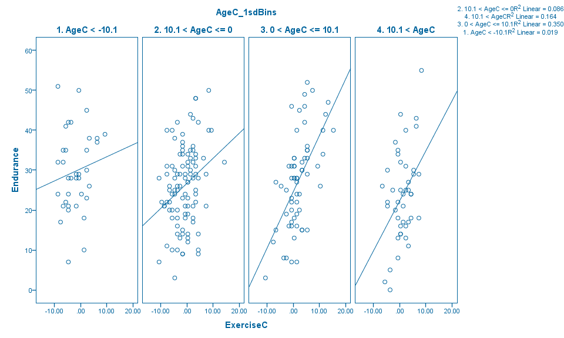

[output not shown]

[output not shown]

[output not shown]

[output not shown]

[output not shown]

[output not shown]